# Майнор "Интеллектуальный анализ данных"

# Курс "Современные методы машинного обучения"

# Лабораторная работа №1. Image Classification.

В данной лабораторной работе вам предлагается обучить модель на основе нейронной сети для распознавания рукописных букв английского алфавита.

## Данные

Данные представлены двумя датасетами: обучающим (`train`) и тестовым (`test`). Изображения для каждого датасета находятся в `images.zip`.

Обучающая выборка состоит из 65000 изображений - по 2500 изображений для каждой буквы.  
Тестовая выборка состоит из 13000 изображений - по 500 изображений для каждой буквы.

Все изображения - монохромные (но в формате RGB), размерности $28 \times 28$ пикселей, в формате JPEG. В названии каждого файла содержатся буква, которая представлена на изображении, и уникальный номер изображения: `a_00002.jpg`.

**NB:** Все изображения представлены в перевернутом виде, для корректного отображения их нужно сначала транспонировать.

```python
import numpy as np
import matplotlib.pyplot as plt
```

## Основные задания

Ваша задача - создать и обучить модель на основе нейронной сети, которая будет предсказывать букву на картинке.  
Обучение необходимо проводить на данных из `train`, качество модели проверять на данных из `test`.  
Целевая метрика - accuracy.  
Для моделирования необходимо использовать `pytorch`.

### Задание 1

*Вес в общей оценке - 0.35*

1. Постройте и обучите модели с 2-мя и 3-мя полносвязными (dense) скрытыми слоями.  
   При моделировании необходимо попробовать разные параметры нейронной сети - число нейронов на каждом слое, learning rate, batch size, функции активации, регуляризации и т.д. Оцените качество моделей с различными параметрами, проведите сравнительный анализ.
2. Для наилучшей модели постройте confusion matrix результатов предсказаний модели на тестовых данных.  
   Насколько равномерно обучилась ваша модель? Приведите буквы с самой лучшей и с самой худшей точностью детекции.
3. Найдите 10 пар букв, которые чаще всего путаются между собой, дайте возможное объяснение. Приведите примеры с картинками, которые были детектированы с ошибкой.
4. Возьмите первую букву вашей фамилии и укажите её точность детекции. С какими буквами ваша модель чаще всего путает эту букву?

```python
import torch
import torchvision
import torchvision.transforms as transforms
```

```python
from google.colab import drive
drive.mount('/content/drive/', force_remount=True)
```

```python
transform = transforms.Compose(
    [transforms.ToTensor(),
     transforms.Normalize((0.5, 0.5, 0.5), (0.5, 0.5, 0.5)),
     transforms.Lambda(lambda pic: np.transpose(pic, axes=(2, 1, 0)))])
```

```python
train_letter_data = torchvision.datasets.ImageFolder(root = '/content/drive/MyDrive/images/train', transform = transform)
train_letter_loader = torch.utils.data.DataLoader(train_letter_data, batch_size=16, num_workers=2, shuffle=True)
```

```python
test_letter_data = torchvision.datasets.ImageFolder(root = '/content/drive/MyDrive/images/test', transform = transform)
test_letter_loader = torch.utils.data.DataLoader(test_letter_data, batch_size=16, num_workers=2, shuffle=True)
```

```python
import torch.nn as nn
import torch.nn.functional as F


class NetTwo(nn.Module):
    def __init__(self, neuron=120):
        super(NetTwo, self).__init__()# 28*28
        self.fc1 = nn.Linear(28*28*3, neuron)
        self.fc2 = nn.Linear(neuron, 26)

    def forward(self, x):
      x = x.view(-1, 28*28*3)
      x = F.relu(self.fc1(x))
      x = self.fc2(x)
      return x

class NetThree(nn.Module):
    def __init__(self, neurons=(600, 120)):
        super(NetThree, self).__init__()# 28*28
        self.fc1 = nn.Linear(28*28*3, neurons[0])
        self.fc2 = nn.Linear(neurons[0], neurons[1])
        self.fc3 = nn.Linear(neurons[1], 26)

    def forward(self, x):
        x = x.view(-1, 28*28*3)
        x = F.relu(self.fc1(x))
        x = F.relu(self.fc2(x))
        x = self.fc3(x)
        return x
```

```python
net = NetTwo()
```

```python
def run_train(epoch, net=net):
  criterion = nn.CrossEntropyLoss()
  optimizer = optim.SGD(net.parameters(), lr=1e-3, momentum=0.7)

  for epoch in range(epoch):  # loop over the dataset multiple times
      total = 0
      correct = 0
      running_loss = 0.0

      for i, data in enumerate(train_letter_loader, 0):
          # get the inputs; data is a list of [inputs, labels]
          inputs, labels = data

          # zero the parameter gradients
          optimizer.zero_grad()

          # forward + backward + optimize
          outputs = net(inputs)

          loss = criterion(outputs, labels)
          loss.backward()
          optimizer.step()

          _, predicted = torch.max(outputs.data, 1)
          total += labels.size(0)
          correct += (predicted == labels).sum().item()

          # print statistics
          running_loss += loss.item()
          if i % 4000 == 3999:    # print every 4000 mini-batches
              print('[%d, %5d] loss: %.3f, accuracy: %.3f' %
                    (epoch + 1, i + 1, running_loss / 4000, correct / total))
              running_loss = 0.0
              total = 0
              correct = 0

  print('Finished Training')
```

```python
def test_model(net=net):
  correct = 0
  total = 0

  with torch.no_grad():
      for data in test_letter_loader:
          images, labels = data
          outputs = net(images)

          _, predicted = torch.max(outputs.data, 1)
          total += labels.size(0)
          correct += (predicted == labels).sum().item()

      print('Accuracy of the network on the 13000 test images: %.2f' % (100 * correct / total))
  return 100 * correct / total
```

```python
def test_classes(net=net):
  class_correct = list(0. for i in range(26))
  class_total = list(0. for i in range(26))

  with torch.no_grad():
      for ind, data in enumerate(test_letter_loader, 0):
          images, labels = data
          outputs = net(images)
          _, predicted = torch.max(outputs, 1)
          c = (predicted == labels).squeeze()
          for i in range(len(labels)):
              label = labels[i]
              class_correct[label] += c[i].item()
              class_total[label] += 1

  for i in range(26):
      print('Accuracy of %5s : %2d %%' % (
          classes[i], 100 * class_correct[i] / class_total[i]))

  return class_correct, class_total
```

```python
import torch.optim as optim

criterion = nn.CrossEntropyLoss()
optimizer = optim.SGD(net.parameters(), lr=1e-3, momentum=0.7)
```

```python
neurons = (60, 120, 600, 1200)
neurons_combos = ((600, 120), (1200, 600), (1200, 120), (600, 60), (120, 60), (1200, 60))
```

```python
results = []
```

```python
for neuron in neurons:
  print('\tneurons number:', neuron)

  PATH = '/content/drive/MyDrive/models/two_layer_'+ str(neuron) + '.pth'

  best_acc = 50
  net = NetTwo(neuron)
  for epoch in range(4, 6):
    print('   Epochs:', epoch)
    run_train(epoch, net)
    accuracy = test_model(net)

    if accuracy > best_acc:
      best_acc = accuracy
      torch.save(net.state_dict(), PATH)

    results.append({'batch-size': 16, 'layers': 2, 'neurons': neuron, 'accuracy': accuracy, 'epoch': epoch})
```

```
	neurons number: 60
   Epochs: 4
[1,  4000] loss: 1.475, accuracy: 0.589
[2,  4000] loss: 1.033, accuracy: 0.699
[3,  4000] loss: 0.904, accuracy: 0.738
[4,  4000] loss: 0.801, accuracy: 0.768
Finished Training
Accuracy of the network on the 13000 test images: 77 %
   Epochs: 5
[1,  4000] loss: 0.723, accuracy: 0.790
[2,  4000] loss: 0.667, accuracy: 0.805
[3,  4000] loss: 0.625, accuracy: 0.816
[4,  4000] loss: 0.591, accuracy: 0.827
[5,  4000] loss: 0.563, accuracy: 0.834
Finished Training
Accuracy of the network on the 13000 test images: 82 %
	neurons number: 120
   Epochs: 4
[1,  4000] loss: 1.450, accuracy: 0.600
[2,  4000] loss: 0.993, accuracy: 0.713
[3,  4000] loss: 0.835, accuracy: 0.760
[4,  4000] loss: 0.715, accuracy: 0.795
Finished Training
Accuracy of the network on the 13000 test images: 79 %
   Epochs: 5
[1,  4000] loss: 0.631, accuracy: 0.818
[2,  4000] loss: 0.573, accuracy: 0.834
[3,  4000] loss: 0.527, accuracy: 0.845
[4,  4000] loss: 0.492, accuracy: 0.853
[5,  4000] loss: 0.465, accuracy: 0.861
Finished Training
Accuracy of the network on the 13000 test images: 85 %
	neurons number: 600
   Epochs: 4
[1,  4000] loss: 1.405, accuracy: 0.611
[2,  4000] loss: 0.951, accuracy: 0.725
[3,  4000] loss: 0.770, accuracy: 0.778
[4,  4000] loss: 0.640, accuracy: 0.815
Finished Training
Accuracy of the network on the 13000 test images: 81 %
```

[output cut: 9 more lines]

```
   Epochs: 4
[1,  4000] loss: 1.369, accuracy: 0.620
[2,  4000] loss: 0.925, accuracy: 0.732
[3,  4000] loss: 0.743, accuracy: 0.786
[4,  4000] loss: 0.619, accuracy: 0.821
Finished Training
Accuracy of the network on the 13000 test images: 82 %
   Epochs: 5
[1,  4000] loss: 0.538, accuracy: 0.844
[2,  4000] loss: 0.479, accuracy: 0.859
[3,  4000] loss: 0.437, accuracy: 0.871
[4,  4000] loss: 0.402, accuracy: 0.882
[5,  4000] loss: 0.375, accuracy: 0.889
Finished Training
Accuracy of the network on the 13000 test images: 86 %
```

```python
print('Best model:')
res = sorted(results, key=lambda t: t['accuracy'], reverse=True)
for r in res:
  print(r)
```

```
Best model:
{'batch-size': 16, 'layers': 2, 'neurons': 600, 'accuracy': 87.3923076923077, 'epoch': 5}
{'batch-size': 16, 'layers': 2, 'neurons': 1200, 'accuracy': 86.96923076923076, 'epoch': 5}
{'batch-size': 16, 'layers': 2, 'neurons': 120, 'accuracy': 85.13846153846154, 'epoch': 5}
{'batch-size': 16, 'layers': 2, 'neurons': 60, 'accuracy': 82.13076923076923, 'epoch': 5}
{'batch-size': 16, 'layers': 2, 'neurons': 1200, 'accuracy': 82.06153846153846, 'epoch': 4}
{'batch-size': 16, 'layers': 2, 'neurons': 600, 'accuracy': 81.56923076923077, 'epoch': 4}
{'batch-size': 16, 'layers': 2, 'neurons': 120, 'accuracy': 79.99230769230769, 'epoch': 4}
{'batch-size': 16, 'layers': 2, 'neurons': 60, 'accuracy': 77.16923076923077, 'epoch': 4}
```

В двухслойных моделях видно, что лучшие значения получаются из 5 эпох.

```python
for neurons in neurons_combos:
  print('\tneurons numbers:', neurons)

  PATH = '/content/drive/MyDrive/models/three_layer_'+ '_'.join([str(n) for n in neurons]) + '.pth'

  best_acc = 50
  net = NetThree(neurons)
  for epoch in range(4, 6):
    print('   Epochs:', epoch)
    run_train(epoch, net)
    accuracy = test_model(net)

    if accuracy > best_acc:
      best_acc = accuracy
      torch.save(net.state_dict(), PATH)

    results.append({'batch-size': 16, 'layers': 3, 'neurons': neurons, 'accuracy': accuracy, 'epoch': epoch})
```

```
	neurons numbers: (600, 120)
   Epochs: 4
[1,  4000] loss: 1.725, accuracy: 0.524
[2,  4000] loss: 1.030, accuracy: 0.698
[3,  4000] loss: 0.828, accuracy: 0.758
[4,  4000] loss: 0.671, accuracy: 0.802
Finished Training
Accuracy of the network on the 13000 test images: 81 %
   Epochs: 5
[1,  4000] loss: 0.568, accuracy: 0.832
[2,  4000] loss: 0.496, accuracy: 0.853
[3,  4000] loss: 0.444, accuracy: 0.867
[4,  4000] loss: 0.402, accuracy: 0.879
[5,  4000] loss: 0.372, accuracy: 0.887
Finished Training
Accuracy of the network on the 13000 test images: 87 %
	neurons numbers: (1200, 600)
   Epochs: 4
[1,  4000] loss: 1.630, accuracy: 0.564
[2,  4000] loss: 0.977, accuracy: 0.713
[3,  4000] loss: 0.763, accuracy: 0.777
[4,  4000] loss: 0.617, accuracy: 0.819
Finished Training
Accuracy of the network on the 13000 test images: 82 %
   Epochs: 5
[1,  4000] loss: 0.527, accuracy: 0.844
[2,  4000] loss: 0.464, accuracy: 0.861
[3,  4000] loss: 0.419, accuracy: 0.873
[4,  4000] loss: 0.383, accuracy: 0.883
[5,  4000] loss: 0.353, accuracy: 0.891
Finished Training
Accuracy of the network on the 13000 test images: 87 %
	neurons numbers: (1200, 120)
   Epochs: 4
[1,  4000] loss: 1.681, accuracy: 0.540
[2,  4000] loss: 1.010, accuracy: 0.704
[3,  4000] loss: 0.799, accuracy: 0.765
[4,  4000] loss: 0.641, accuracy: 0.811
Finished Training
Accuracy of the network on the 13000 test images: 81 %
```

[output cut: 41 more lines]

```
   Epochs: 4
[1,  4000] loss: 1.661, accuracy: 0.547
[2,  4000] loss: 1.010, accuracy: 0.704
[3,  4000] loss: 0.799, accuracy: 0.765
[4,  4000] loss: 0.643, accuracy: 0.811
Finished Training
Accuracy of the network on the 13000 test images: 82 %
   Epochs: 5
[1,  4000] loss: 0.542, accuracy: 0.839
[2,  4000] loss: 0.474, accuracy: 0.856
[3,  4000] loss: 0.423, accuracy: 0.872
[4,  4000] loss: 0.385, accuracy: 0.883
[5,  4000] loss: 0.354, accuracy: 0.891
Finished Training
Accuracy of the network on the 13000 test images: 87 %
```

```python
print('Best model:')
res = sorted(results, key=lambda t: t['accuracy'], reverse=True)
for r in res:
  print(r)
```

[output not shown]

Результаты таковы, что количество слоев не сильно влияет на точность, так как они расположены вперемежку.

Влияние количества нейронов тоже сложно измерить, но наверно можно сказать, что чем больше на первом слое нейронов (из выбранных) и чем сильнее разница между слоями для трехслойных, тем лучше обучается модель.

Лучшая модель получается трехслойная с нейронами 1200 и 60. Загрузим ее:

```python
classes = test_letter_data.classes
params = {'batch-size': 16, 'layers': 3, 'neurons': (1200, 60), 'accuracy': 87.70769230769231, 'epoch': 5}     #res[0]
print(params)
net_best = NetThree(params['neurons'])
path = '/content/drive/MyDrive/models/three_layer_'+ '_'.join([str(n) for n in params['neurons']]) + '.pth'
net_best.load_state_dict(torch.load(path))
```

```
{'batch-size': 16, 'layers': 3, 'neurons': (1200, 60), 'accuracy': 87.70769230769231, 'epoch': 5}
```

```
<All keys matched successfully>
```

Проверим, что эта модель действительно имеет такую accuracy:

```python
print(test_model(net_best))
```

```
Accuracy of the network on the 13000 test images: 87.71
87.70769230769231
```

Какие буквы модель распознает лучше и хуже всего:

```python
class_correct, class_total = test_classes(net_best)
```

```
Accuracy of     a : 82 %
Accuracy of     b : 91 %
Accuracy of     c : 91 %
Accuracy of     d : 89 %
Accuracy of     e : 91 %
Accuracy of     f : 86 %
Accuracy of     g : 71 %
Accuracy of     h : 88 %
Accuracy of     i : 70 %
Accuracy of     j : 87 %
Accuracy of     k : 88 %
Accuracy of     l : 74 %
Accuracy of     m : 92 %
Accuracy of     n : 88 %
Accuracy of     o : 97 %
Accuracy of     p : 90 %
Accuracy of     q : 80 %
Accuracy of     r : 86 %
Accuracy of     s : 93 %
Accuracy of     t : 95 %
Accuracy of     u : 90 %
Accuracy of     v : 90 %
Accuracy of     w : 95 %
Accuracy of     x : 93 %
Accuracy of     y : 83 %
Accuracy of     z : 90 %
```

```python
acc_classes = {classes[i]: 100 * class_correct[i] / class_total[i] for i in range(26)}
acc_sorted = sorted(acc_classes.items(), key=lambda t: t[-1], reverse=True)
print(acc_sorted[0])
print(acc_sorted[-1])
```

```
('o', 97.6)
('i', 70.0)
```

```python
from sklearn.metrics import confusion_matrix

predict = []
total = []
with torch.no_grad():
    for data in test_letter_loader:
        images, labels = data

        outputs = net_best(images)
        _, predicted = torch.max(outputs.data, 1)

        total.extend(labels)
        predict.extend(predicted)

conf_matrix = confusion_matrix(total, predict)
```

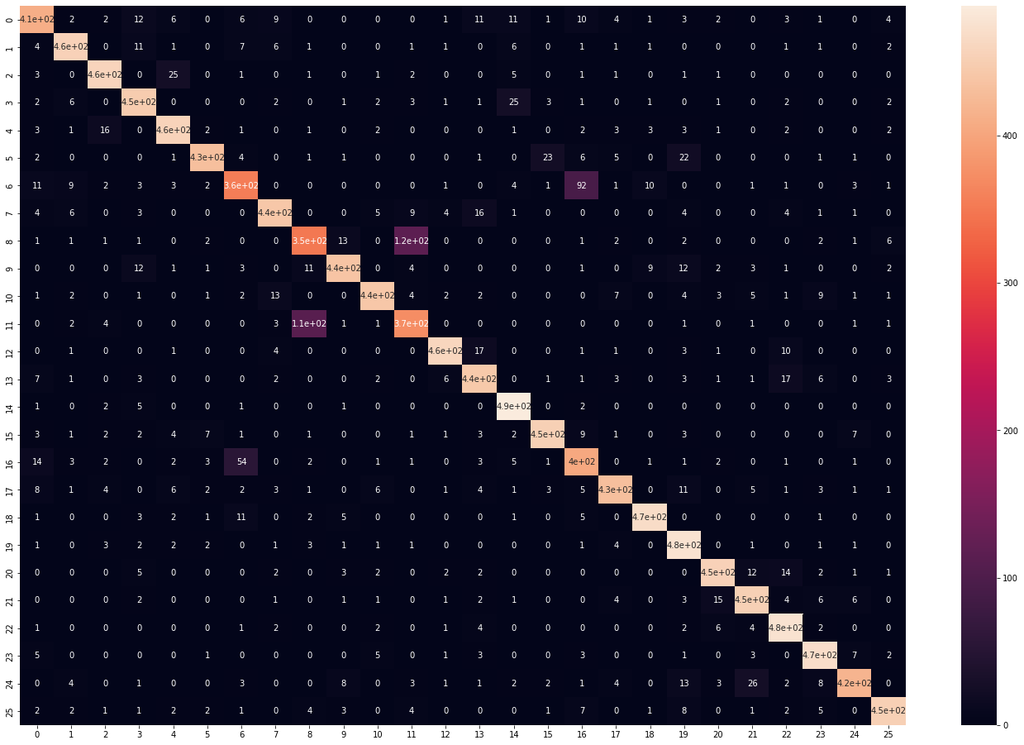

```python
import seaborn as sns

plt.figure(figsize=(24,16))
sns.heatmap(conf_matrix, annot=True)
plt.show()
```

→ Predicted; ↓ Actual

Судя по матрице, модель обучилась довольно равномерно, всего 4 ярких всплеска ошибок. Их мы увидим далее.

```python
confuses = {}

for i, row in enumerate(conf_matrix):
  maximum = sorted(conf_matrix[i], reverse=True)[1]
  confuses[tuple([classes[i], classes[list(conf_matrix[i]).index(maximum)]])] = maximum

confs_sorted = sorted(confuses.items(), key=lambda t: t[-1], reverse=True)
confs_sorted[:10]
```

```
[(('i', 'l'), 117),
 (('l', 'i'), 112),
 (('g', 'q'), 92),
 (('q', 'g'), 54),
 (('y', 'v'), 26),
 (('c', 'e'), 25),
 (('d', 'o'), 25),
 (('f', 'p'), 23),
 (('m', 'n'), 17),
 (('n', 'w'), 17)]
```

Логично, что буквы *I* и *L* путаются чаще всего, так как выглядят они очень похожо (вертикальная палка с пробелом или без)

Буквы *G* и *Q* также довольно похожы ("хвостик" прямой или загнутый), то же относительно букв **Y** и **V**; **C** и **E**; **D** и **O**; **M** и **N**

Интересны случаи **F** и **P**; **N** и **W**: возможно n и w похожи друг на друга, но перевернутые, а f и p, вероятно, на картинках выглядят тоже похоже (с замкнутым кругом или нет)

Посмотрим на картинки:

```python
confusion_dict = {val[0][-1]: val[0][0] for val in confs_sorted[:10]}
confusion_dict
```

```
{'e': 'c',
 'g': 'q',
 'i': 'l',
 'l': 'i',
 'n': 'm',
 'o': 'd',
 'p': 'f',
 'q': 'g',
 'v': 'y',
 'w': 'n'}
```

```
Clipping input data to the valid range for imshow with RGB data ([0..1] for floats or [0..255] for integers).
```

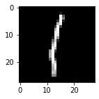

```
True: i 	Predicted: l
```

```
Clipping input data to the valid range for imshow with RGB data ([0..1] for floats or [0..255] for integers).
```

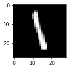

```
Clipping input data to the valid range for imshow with RGB data ([0..1] for floats or [0..255] for integers).
```

```
True: l 	Predicted: i
```

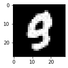

```
True: q 	Predicted: g
```

```
Clipping input data to the valid range for imshow with RGB data ([0..1] for floats or [0..255] for integers).
```

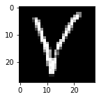

```
True: v 	Predicted: y
```

```
Clipping input data to the valid range for imshow with RGB data ([0..1] for floats or [0..255] for integers).
```

[figure not shown]

```
True: g 	Predicted: q
```

```
Clipping input data to the valid range for imshow with RGB data ([0..1] for floats or [0..255] for integers).
```

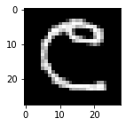

```
True: e 	Predicted: c
```

```
Clipping input data to the valid range for imshow with RGB data ([0..1] for floats or [0..255] for integers).
```

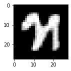

```
Clipping input data to the valid range for imshow with RGB data ([0..1] for floats or [0..255] for integers).
```

```
True: n 	Predicted: m
```

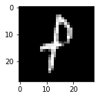

```
True: p 	Predicted: f
```

```
Clipping input data to the valid range for imshow with RGB data ([0..1] for floats or [0..255] for integers).
```

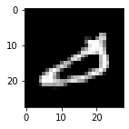

```
True: o 	Predicted: d
```

```
Clipping input data to the valid range for imshow with RGB data ([0..1] for floats or [0..255] for integers).
```

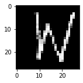

```
True: w 	Predicted: n
```

```python
 counter = [0 for i in range(26)]
 with torch.no_grad():
      for i, data in enumerate(test_letter_loader, 0):
          images, labels = data

          if any(classes[k] in confusion_dict.keys() for k in labels):
            outputs = net_best(images)
            _, predicted = torch.max(outputs, 1)

            for ind, letter in enumerate(labels):
              if classes[letter] in confusion_dict.keys() and \
              confusion_dict[classes[letter]] == classes[predicted[ind]] and \
              counter[letter] < 1:

                counter[letter] = counter[letter]+1
                plt.figure(figsize=(2,2))
                plt.imshow(images[ind])
                plt.show()
                print('True:', classes[letter], '\tPredicted:', classes[predicted[ind]])
```

По картинкам мы видим, что дейсвительно все True буквы похожи на Predicted в таком написании, а w, вероятно, похожа на заглавную N

Посмотрим на первую букву моей фамилии K:

```python
print('Точность детекции:', acc_classes['k'])
```

```
Точность детекции: 88.2
```

```
Clipping input data to the valid range for imshow with RGB data ([0..1] for floats or [0..255] for integers).
```

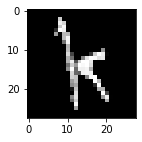

```
Clipping input data to the valid range for imshow with RGB data ([0..1] for floats or [0..255] for integers).
```

```
True: k 	Predicted: x
```

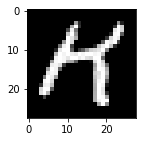

```
Clipping input data to the valid range for imshow with RGB data ([0..1] for floats or [0..255] for integers).
```

```
True: k 	Predicted: h
```

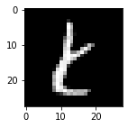

```
True: k 	Predicted: t
```

```
Clipping input data to the valid range for imshow with RGB data ([0..1] for floats or [0..255] for integers).
```

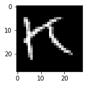

```
True: k 	Predicted: n
```

```
Clipping input data to the valid range for imshow with RGB data ([0..1] for floats or [0..255] for integers).
```

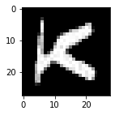

```
Clipping input data to the valid range for imshow with RGB data ([0..1] for floats or [0..255] for integers).
```

```
True: k 	Predicted: x
```

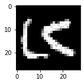

```
True: k 	Predicted: w
```

```
Clipping input data to the valid range for imshow with RGB data ([0..1] for floats or [0..255] for integers).
```

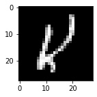

```
True: k 	Predicted: v
```

```
Clipping input data to the valid range for imshow with RGB data ([0..1] for floats or [0..255] for integers).
```

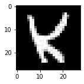

```
True: k 	Predicted: x
```

```
Clipping input data to the valid range for imshow with RGB data ([0..1] for floats or [0..255] for integers).
```

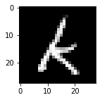

```
True: k 	Predicted: h
```

```
Clipping input data to the valid range for imshow with RGB data ([0..1] for floats or [0..255] for integers).
```

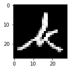

```
True: k 	Predicted: h
```

```
Clipping input data to the valid range for imshow with RGB data ([0..1] for floats or [0..255] for integers).
```

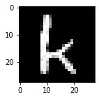

```
Clipping input data to the valid range for imshow with RGB data ([0..1] for floats or [0..255] for integers).
```

```
True: k 	Predicted: h
```

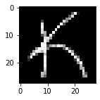

```
True: k 	Predicted: h
```

```
Clipping input data to the valid range for imshow with RGB data ([0..1] for floats or [0..255] for integers).
```

[47 more figures not shown]

```
True: k 	Predicted: r
```

```python
 false_predictions = {}

 with torch.no_grad():
      for i, data in enumerate(test_letter_loader, 0):
          images, labels = data

          if (list(classes)).index('k') in labels:  # index of k is 10
            outputs = net_best(images)
            _, predicted = torch.max(outputs, 1)

            for ind, letter in enumerate(labels):
              if int(letter) == 10 and int(predicted[ind]) != 10:
                plt.figure(figsize=(2,2))
                plt.imshow(images[ind])
                plt.show()
                print('True:', classes[letter], '\tPredicted:', classes[predicted[ind]])
                false_predictions[classes[predicted[ind]]] = false_predictions.get(classes[predicted[ind]], 0) + 1

sorted_false = confs_sorted = sorted(false_predictions.items(), key=lambda t: t[-1], reverse=True)
```

```python
sorted_false
```

```
[('h', 13),
 ('x', 9),
 ('r', 7),
 ('v', 5),
 ('t', 4),
 ('l', 4),
 ('u', 3),
 ('n', 2),
 ('b', 2),
 ('m', 2),
 ('g', 2),
 ('w', 1),
 ('d', 1),
 ('z', 1),
 ('f', 1),
 ('a', 1),
 ('y', 1)]
```

Чаще всего модель путает первую букву моей фамилии с буквами h, x и r. Остальные данные видно в клетке выше. В целом модель путает букву k с 17 другими буквами.

### Задание 2

*Вес в общей оценке - 0.35*

1. Постройте и обучите модели нейронной сети с 1-м, 2-мя и 3-мя сверточными слоями.  
   Попробуйте различные значения параметров сверток и числа фильтров на каждом слое. Оцените качество моделей с различными параметрами, проведите сравнительный анализ.
2. Для наилучшей конфигурации из предыдущего пункта, сравните, как меняется качество модели при увеличении размера батча при использовании BatchNorm и GroupNorm.

```python
transform = transforms.Compose(
    [transforms.ToTensor(),
     transforms.Normalize((0.5, 0.5, 0.5), (0.5, 0.5, 0.5)),
     transforms.Lambda(lambda pic: np.transpose(pic, axes=(0, 2, 1)))])
```

```python
train_letter_data = torchvision.datasets.ImageFolder(root = '/content/drive/MyDrive/images/train', transform = transform)
train_letter_loader = torch.utils.data.DataLoader(train_letter_data, batch_size=16, num_workers=2, shuffle=True)
```

```python
test_letter_data = torchvision.datasets.ImageFolder(root = '/content/drive/MyDrive/images/test', transform = transform)
test_letter_loader = torch.utils.data.DataLoader(test_letter_data, batch_size=16, num_workers=2, shuffle=True)
```

```python
import torch.nn as nn
import torch.nn.functional as F

class NetConv(nn.Module):
    def __init__(self, channel=6, kernel=5):
        super(NetConv, self).__init__() #28*28
        self.conv1 = nn.Conv2d(3, channel, kernel) #24*24
        self.fc = nn.Linear(((28-kernel+1)**2)*channel, 26)
        self.channel = channel
        self.kernel = kernel

    def forward(self, x):
      x = F.relu(self.conv1(x))
      x = x.view(-1, ((28-self.kernel+1)**2)*self.channel)
      x = self.fc(x)
      return x
```

```python
class NetTwoConv(nn.Module):
    def __init__(self, channels=(6, 16), kernels=(5, 5)):
        super(NetTwoConv, self).__init__()# 28*28
        self.conv1 = nn.Conv2d(3, channels[0], kernels[0]) #24*24
        self.conv2 = nn.Conv2d(channels[0], channels[1], kernels[1]) #20*20
        self.fc = nn.Linear(((28-sum(kernels)+2)**2)*channels[1], 26)
        self.channels = channels
        self.kernels = kernels

    def forward(self, x):
        x = F.relu(self.conv1(x))
        x = F.relu(self.conv2(x))
        x = x.view(-1, ((28-sum(self.kernels)+2)**2)*self.channels[1])
        x = self.fc(x)
        return x
```

```python
class NetThreeConv(nn.Module):
    def __init__(self, channels=(6, 16, 32), kernels=(5, 5, 3)):
        super(NetThreeConv, self).__init__()# 28*28
        self.conv1 = nn.Conv2d(3, channels[0], kernels[0]) #28*28
        self.conv2 = nn.Conv2d(channels[0], channels[1], kernels[1]) #24*24
        self.conv3 = nn.Conv2d(channels[1], channels[2], kernels[2]) #22*22
        self.fc = nn.Linear(((28-sum(kernels)+3)**2)*channels[2], 26)
        self.channels = channels
        self.kernels = kernels

    def forward(self, x):
        x = F.relu(self.conv1(x))
        x = F.relu(self.conv2(x))
        x = F.relu(self.conv3(x))
        x = x.view(-1, ((28-sum(self.kernels)+3)**2)*self.channels[2])
        x = self.fc(x)
        return x
```

```python
import torch.optim as optim

criterion = nn.CrossEntropyLoss()
optimizer = optim.SGD(net.parameters(), lr=1e-3, momentum=0.7)  # 62%
```

```python
results_conv = []
```

```python
conv_1_combos = [(6, 5), (12, 5), (24, 5), (6, 9), (12, 9), (24, 9)]
conv_2_combos = [((6, 12), (5, 5)), ((12, 16), (5, 5)), ((16, 24), (5, 5)), ((6, 12), (5, 3)), ((12, 16), (9, 5)), ((16, 24), (9, 5)),  ((16, 24), (5, 3))]
conv_3_combos = [((12, 24, 36), (5, 5, 5)), ((12, 24, 48), (5, 5, 5)), ((12, 16, 24), (9, 9, 5)), ((12, 24, 36), (9, 9, 5))]
```

Так как на прошлых моделях мы выяснили, что 5 эпох работает лучше, будем сразу использовать это число.

```python
best_acc = 50

for combo in conv_1_combos:
  print('\tlayers/kernel numbers:', *combo)

  PATH = '/content/drive/MyDrive/models/one_conv_'+ '_'.join([str(n) for n in combo]) + '.pth'

  net = NetConv(combo[0], combo[1])
  epoch = 5
  run_train(epoch, net)
  accuracy = test_model(net)

  if accuracy > best_acc:
    best_acc = accuracy
    torch.save(net.state_dict(), PATH)

  results_conv.append({'layers': 1, 'vars': combo, 'accuracy': accuracy})
  results.append({'layers': 1, 'type': 'conv', 'vars': combo, 'accuracy': accuracy})
```

```
	layers/kernel numbers: 6 5
[1,  4000] loss: 1.122, accuracy: 0.669
[2,  4000] loss: 0.639, accuracy: 0.809
[3,  4000] loss: 0.512, accuracy: 0.844
```

[output not shown]

```
[4,  4000] loss: 0.456, accuracy: 0.860
[5,  4000] loss: 0.424, accuracy: 0.868
Finished Training
Accuracy of the network on the 13000 test images: 85 %
	layers/kernel numbers: 12 5
[1,  4000] loss: 1.028, accuracy: 0.701
[2,  4000] loss: 0.571, accuracy: 0.829
[3,  4000] loss: 0.463, accuracy: 0.858
[4,  4000] loss: 0.410, accuracy: 0.874
[5,  4000] loss: 0.375, accuracy: 0.883
Finished Training
Accuracy of the network on the 13000 test images: 87 %
	layers/kernel numbers: 24 5
[1,  4000] loss: 0.920, accuracy: 0.728
[2,  4000] loss: 0.506, accuracy: 0.846
[3,  4000] loss: 0.425, accuracy: 0.869
[4,  4000] loss: 0.382, accuracy: 0.882
[5,  4000] loss: 0.351, accuracy: 0.889
Finished Training
Accuracy of the network on the 13000 test images: 87 %
	layers/kernel numbers: 6 9
[1,  4000] loss: 0.932, accuracy: 0.724
[2,  4000] loss: 0.534, accuracy: 0.837
[3,  4000] loss: 0.456, accuracy: 0.859
[4,  4000] loss: 0.414, accuracy: 0.871
[5,  4000] loss: 0.387, accuracy: 0.879
Finished Training
Accuracy of the network on the 13000 test images: 87 %
	layers/kernel numbers: 12 9
[1,  4000] loss: 0.874, accuracy: 0.741
[2,  4000] loss: 0.484, accuracy: 0.851
[3,  4000] loss: 0.406, accuracy: 0.874
[4,  4000] loss: 0.364, accuracy: 0.886
[5,  4000] loss: 0.336, accuracy: 0.893
Finished Training
Accuracy of the network on the 13000 test images: 88 %
	layers/kernel numbers: 24 9
[1,  4000] loss: 0.838, accuracy: 0.752
[2,  4000] loss: 0.460, accuracy: 0.858
[3,  4000] loss: 0.380, accuracy: 0.881
[4,  4000] loss: 0.336, accuracy: 0.893
[5,  4000] loss: 0.311, accuracy: 0.901
Finished Training
Accuracy of the network on the 13000 test images: 89 %
```

```python
best_acc = 50

for combo in conv_2_combos:
  print('\tlayers/kernel numbers:', *combo)

  PATH = '/content/drive/MyDrive/models/two_conv_'+ '_'.join([str(n[0])+'-'+str(n[-1]) for n in combo]) + '.pth'  #two

  net = NetTwoConv(combo[0], combo[1])
  epoch = 5
  run_train(epoch, net)
  accuracy = test_model(net)

  if accuracy > best_acc:
    best_acc = accuracy
    torch.save(net.state_dict(), PATH)

  results_conv.append({'layers': 2, 'vars': combo, 'accuracy': accuracy})
```

```
	layers/kernel numbers: (6, 12) (5, 5)
```

[output not shown]

```
[1,  4000] loss: 0.991, accuracy: 0.711
[2,  4000] loss: 0.467, accuracy: 0.855
[3,  4000] loss: 0.394, accuracy: 0.878
[4,  4000] loss: 0.356, accuracy: 0.889
[5,  4000] loss: 0.324, accuracy: 0.898
Finished Training
Accuracy of the network on the 13000 test images: 89.55
	layers/kernel numbers: (12, 16) (5, 5)
[1,  4000] loss: 0.941, accuracy: 0.725
[2,  4000] loss: 0.436, accuracy: 0.866
[3,  4000] loss: 0.356, accuracy: 0.889
[4,  4000] loss: 0.311, accuracy: 0.902
[5,  4000] loss: 0.283, accuracy: 0.910
Finished Training
Accuracy of the network on the 13000 test images: 89.80
	layers/kernel numbers: (16, 24) (5, 5)
[1,  4000] loss: 0.911, accuracy: 0.731
[2,  4000] loss: 0.428, accuracy: 0.868
[3,  4000] loss: 0.344, accuracy: 0.893
[4,  4000] loss: 0.299, accuracy: 0.907
[5,  4000] loss: 0.268, accuracy: 0.914
Finished Training
Accuracy of the network on the 13000 test images: 89.86
	layers/kernel numbers: (6, 12) (5, 3)
[1,  4000] loss: 1.081, accuracy: 0.682
[2,  4000] loss: 0.533, accuracy: 0.838
[3,  4000] loss: 0.437, accuracy: 0.866
[4,  4000] loss: 0.386, accuracy: 0.880
[5,  4000] loss: 0.349, accuracy: 0.891
Finished Training
Accuracy of the network on the 13000 test images: 88.52
	layers/kernel numbers: (12, 16) (9, 5)
[1,  4000] loss: 0.910, accuracy: 0.730
[2,  4000] loss: 0.453, accuracy: 0.860
[3,  4000] loss: 0.375, accuracy: 0.883
[4,  4000] loss: 0.331, accuracy: 0.895
[5,  4000] loss: 0.299, accuracy: 0.904
Finished Training
Accuracy of the network on the 13000 test images: 89.61
	layers/kernel numbers: (16, 24) (9, 5)
[1,  4000] loss: 0.902, accuracy: 0.733
[2,  4000] loss: 0.438, accuracy: 0.865
[3,  4000] loss: 0.350, accuracy: 0.888
[4,  4000] loss: 0.301, accuracy: 0.904
[5,  4000] loss: 0.269, accuracy: 0.913
Finished Training
Accuracy of the network on the 13000 test images: 90.84
	layers/kernel numbers: (16, 24) (5, 3)
[1,  4000] loss: 0.972, accuracy: 0.716
[2,  4000] loss: 0.477, accuracy: 0.854
[3,  4000] loss: 0.389, accuracy: 0.880
[4,  4000] loss: 0.341, accuracy: 0.894
[5,  4000] loss: 0.311, accuracy: 0.901
Finished Training
Accuracy of the network on the 13000 test images: 89.35
```

```python
best_acc = 50

for combo in conv_3_combos:
  print('\tlayers/kernel numbers:', *combo)

  PATH = '/content/drive/MyDrive/models/three_conv_'+ '_'.join([str(n[0])+'-'+str(n[1])+'-'+str(n[2]) for n in combo]) + '.pth'

  net = NetThreeConv(combo[0], combo[1])
  epoch = 5
  run_train(epoch, net)
  accuracy = test_model(net)

  if accuracy > best_acc:
    best_acc = accuracy
    torch.save(net.state_dict(), PATH)

  results_conv.append({'layers': 3, 'vars': combo, 'accuracy': accuracy})
```

```
	layers/kernel numbers: (12, 24, 36) (5, 5, 5)
[1,  4000] loss: 0.954, accuracy: 0.718
[2,  4000] loss: 0.425, accuracy: 0.866
[3,  4000] loss: 0.327, accuracy: 0.895
[4,  4000] loss: 0.275, accuracy: 0.910
[5,  4000] loss: 0.243, accuracy: 0.921
Finished Training
Accuracy of the network on the 13000 test images: 90.24
	layers/kernel numbers: (12, 24, 48) (5, 5, 5)
[1,  4000] loss: 0.885, accuracy: 0.737
[2,  4000] loss: 0.407, accuracy: 0.873
[3,  4000] loss: 0.316, accuracy: 0.899
[4,  4000] loss: 0.267, accuracy: 0.913
[5,  4000] loss: 0.233, accuracy: 0.922
Finished Training
Accuracy of the network on the 13000 test images: 90.83
	layers/kernel numbers: (12, 16, 24) (9, 9, 5)
[1,  4000] loss: 1.132, accuracy: 0.664
[2,  4000] loss: 0.488, accuracy: 0.848
[3,  4000] loss: 0.387, accuracy: 0.877
[4,  4000] loss: 0.335, accuracy: 0.892
[5,  4000] loss: 0.305, accuracy: 0.901
Finished Training
Accuracy of the network on the 13000 test images: 89.73
	layers/kernel numbers: (12, 24, 36) (9, 9, 5)
[1,  4000] loss: 1.139, accuracy: 0.662
[2,  4000] loss: 0.432, accuracy: 0.862
[3,  4000] loss: 0.338, accuracy: 0.891
[4,  4000] loss: 0.295, accuracy: 0.903
[5,  4000] loss: 0.267, accuracy: 0.911
Finished Training
Accuracy of the network on the 13000 test images: 90.95
```

```python
print('Top models:')
res = sorted(results_conv, key=lambda t: t['accuracy'], reverse=True)
for r in res:
  print(r)
```

```
Top models:
{'layers': 3, 'vars': ((12, 24, 36), (9, 9, 5)), 'accuracy': 90.94615384615385}
{'layers': 2, 'vars': ((16, 24), (9, 5)), 'accuracy': 90.83846153846154}
{'layers': 3, 'vars': ((12, 24, 48), (5, 5, 5)), 'accuracy': 90.83076923076923}
{'layers': 3, 'vars': ((12, 24, 36), (5, 5, 5)), 'accuracy': 90.23846153846154}
{'layers': 2, 'vars': ((16, 24), (5, 5)), 'accuracy': 89.86153846153846}
{'layers': 2, 'vars': ((12, 16), (5, 5)), 'accuracy': 89.8}
{'layers': 3, 'vars': ((12, 16, 24), (9, 9, 5)), 'accuracy': 89.73076923076923}
{'layers': 2, 'vars': ((12, 16), (9, 5)), 'accuracy': 89.6076923076923}
{'layers': 2, 'vars': ((6, 12), (5, 5)), 'accuracy': 89.54615384615384}
{'layers': 2, 'vars': ((16, 24), (5, 3)), 'accuracy': 89.34615384615384}
{'layers': 1, 'vars': (24, 9), 'accuracy': 89.21538461538462}
{'layers': 2, 'vars': ((6, 12), (5, 3)), 'accuracy': 88.51538461538462}
{'layers': 1, 'vars': (12, 9), 'accuracy': 88.06153846153846}
{'layers': 1, 'vars': (6, 9), 'accuracy': 87.27692307692308}
{'layers': 1, 'vars': (24, 5), 'accuracy': 87.26153846153846}
{'layers': 1, 'vars': (12, 5), 'accuracy': 87.16153846153846}
{'layers': 1, 'vars': (6, 5), 'accuracy': 85.68461538461538}
```

В среднем модели с тремя слоями обучаются лучше. Также видно, что чем больше слоев из выбранных, тем лучше результат, а вот увеличение kernel size далеко не всегда ведет к улучшению результата.

Параметры лучшей модели видно в первой строчке списка.

```python
classes = test_letter_data.classes
params = {'layers': 3, 'vars': ((12, 24, 36), (9, 9, 5)), 'accuracy': 90.94615384615385} #res[0]
print(params)
net_best = NetThreeConv(*params['vars'])
path = '/content/drive/MyDrive/models/three_conv_'+ '_'.join([str(n[0])+'-'+str(n[1])+'-'+str(n[2]) for n in params['vars']]) + '.pth'
net_best.load_state_dict(torch.load(path))
```

```
{'layers': 3, 'vars': ((12, 24, 36), (9, 9, 5)), 'accuracy': 90.94615384615385}
```

```
<All keys matched successfully>
```

Проверим, что эта модель действительно имеет такую accuracy:

```python
print(test_model(net_best))
```

```
Accuracy of the network on the 13000 test images: 90.95
90.94615384615385
```

1. Для наилучшей конфигурации из предыдущего пункта, сравните, как меняется качество модели при увеличении размера батча при использовании BatchNorm и GroupNorm.

```python
class NetThreeConvBatch(nn.Module):
    def __init__(self, channels=(6, 16, 32), kernels=(5, 5, 3)):
        super(NetThreeConvBatch, self).__init__()# 28*28
        self.conv1 = nn.Conv2d(3, channels[0], kernels[0]) #28*28
        self.conv2 = nn.Conv2d(channels[0], channels[1], kernels[1]) #24*24
        self.conv2_bn = nn.BatchNorm2d(channels[1])
        self.conv3 = nn.Conv2d(channels[1], channels[2], kernels[2]) #22*22
        self.conv3_bn = nn.BatchNorm2d(channels[2])
        self.fc = nn.Linear(((28-sum(kernels)+3)**2)*channels[2], 26)
        self.channels = channels
        self.kernels = kernels

    def forward(self, x):
        x = F.relu(self.conv1(x))
        x = F.relu(self.conv2_bn(self.conv2(x)))
        x = F.relu(self.conv3_bn(self.conv3(x)))
        x = x.view(-1, ((28-sum(self.kernels)+3)**2)*self.channels[2])
        x = self.fc(x)
        return x
```

```python
net_batch = NetThreeConvBatch(*params['vars'])
run_train(5, net_batch)
test_model(net_batch)
```

```
[1,  4000] loss: 0.703, accuracy: 0.793
[2,  4000] loss: 0.364, accuracy: 0.883
[3,  4000] loss: 0.307, accuracy: 0.901
[4,  4000] loss: 0.275, accuracy: 0.910
[5,  4000] loss: 0.256, accuracy: 0.915
Finished Training
Accuracy of the network on the 13000 test images: 91.20
```

```
91.2
```

```python
class NetThreeConvGroup(nn.Module):
    def __init__(self, channels=(6, 16, 32), kernels=(5, 5, 3)):
        super(NetThreeConvGroup, self).__init__()# 28*28
        self.conv1 = nn.Conv2d(3, channels[0], kernels[0]) #28*28
        self.conv2 = nn.Conv2d(channels[0], channels[1], kernels[1]) #24*24
        self.conv2_gn = nn.GroupNorm(4, channels[1])
        self.conv3 = nn.Conv2d(channels[1], channels[2], kernels[2]) #22*22
        self.conv3_gn = nn.GroupNorm(4, channels[2])
        self.fc = nn.Linear(((28-sum(kernels)+3)**2)*channels[2], 26)
        self.channels = channels
        self.kernels = kernels

    def forward(self, x):
        x = F.relu(self.conv1(x))
        x = F.relu(self.conv2_gn(self.conv2(x)))
        x = F.relu(self.conv3_gn(self.conv3(x)))
        x = x.view(-1, ((28-sum(self.kernels)+3)**2)*self.channels[2])
        x = self.fc(x)
        return x
```

```python
net_group = NetThreeConvGroup(*params['vars'])
run_train(5, net_group)
test_model(net_group)
```

```
[1,  4000] loss: 0.718, accuracy: 0.786
[2,  4000] loss: 0.353, accuracy: 0.886
[3,  4000] loss: 0.294, accuracy: 0.903
[4,  4000] loss: 0.265, accuracy: 0.911
[5,  4000] loss: 0.244, accuracy: 0.919
Finished Training
Accuracy of the network on the 13000 test images: 91.37
```

```
91.36923076923077
```

```python
class NetThreeConvBG(nn.Module):
    def __init__(self, channels=(6, 16, 32), kernels=(5, 5, 3)):
        super(NetThreeConvBG, self).__init__()# 28*28
        self.conv1 = nn.Conv2d(3, channels[0], kernels[0]) #28*28
        self.conv2 = nn.Conv2d(channels[0], channels[1], kernels[1]) #24*24
        self.conv2_bn = nn.BatchNorm2d(channels[1])
        self.conv3 = nn.Conv2d(channels[1], channels[2], kernels[2]) #22*22
        self.conv3_gn = nn.GroupNorm(4, channels[2])
        self.fc = nn.Linear(((28-sum(kernels)+3)**2)*channels[2], 26)
        self.channels = channels
        self.kernels = kernels

    def forward(self, x):
        x = F.relu(self.conv1(x))
        x = F.relu(self.conv2_bn(self.conv2(x)))
        x = F.relu(self.conv3_gn(self.conv3(x)))
        x = x.view(-1, ((28-sum(self.kernels)+3)**2)*self.channels[2])
        x = self.fc(x)
        return x
```

```python
net_bg = NetThreeConvBG(*params['vars'])
run_train(5, net_bg)
test_model(net_bg)
```

```
[1,  4000] loss: 0.691, accuracy: 0.792
[2,  4000] loss: 0.352, accuracy: 0.886
[3,  4000] loss: 0.294, accuracy: 0.903
[4,  4000] loss: 0.265, accuracy: 0.913
[5,  4000] loss: 0.246, accuracy: 0.918
Finished Training
Accuracy of the network on the 13000 test images: 91.33
```

```
91.33076923076923
```

В среднем нормализация улучшила результат на 0,35%. GroupNorm сработала на 1,7 десятую лучше, а комбинированние их дало чуть худший результат.

### Задание 3

Обучите модель с точностью (accuracy) на тестовых данных:

- `>= 0.85` +1 балл
- `>= 0.95` +2 балла
- `>= 0.99` +3 балла

Изменение параметров трехслойной сверточной сети не привело к сильному улучшению результата (максимум 94.39, см. предобученные модели, vgg19 - 2 эпохи и тестирование заняли ~8 часов, а 3 эпохи и тестирование >12, поэтому проверить 3 эпохи мне не удалось)

```python
data = ((24, 48, 96), (9, 9, 9))

print('\t', *data)
net_max_gr = NetThreeConvGroup(*data)
run_train(4, net_max_gr)

PATH = '/content/drive/MyDrive/models/optimal_with_group.pth'
torch.save(net_max_gr.state_dict(), PATH)

test_model(net_max_gr)
```

```
	 (24, 48, 96) (9, 9, 9)
[1,  4000] loss: 0.624, accuracy: 0.816
[2,  4000] loss: 0.290, accuracy: 0.906
[3,  4000] loss: 0.238, accuracy: 0.920
[4,  4000] loss: 0.209, accuracy: 0.928
Finished Training
Accuracy of the network on the 13000 test images: 92.08
```

```
92.08461538461539
```

## Бонусные задания

**Задание 1 (1 балл).**

Напишите на листке белой бумаги (маркером или ручкой) от 5 разных букв (можно больше 5 букв в целом с повторениями, но должно быть минимум 5 разных) английского алфавита (в датасете есть как прописные, так и строчные буквы). Сфотографируйте букву и приведите её картинку к размеру $28\times28$ и, желательно, к чёрно-белой палитре цветов. Передайте получившиеся изображения вашей модели и выполните предсказание, оцените результат.

**Tips:**

- В датасете все буквы занимают практически всё пространство картинки по высоте или ширине (или вместе). Если ваша буква будет слишком маленькой или большой, это может повлиять на результат детекции.
- Помните, что буква должна быть белого цвета, а фон - чёрного.
- Описание ваших действий при выполнении этого задания (что вы использовали, чтобы привести картинку к нужному виду) категорически приветствуется :)

**Ход выполнения задания:**

1. На листе бумаги маркером я написала буквы своего имени
2. Сфотографировала их на камеру телефона
3. Умной вырезкой удалила фон букв прямо в галерее
4. В формате PNG перенесла на компьютер, где в paint изменила размерность до квадрата (расстянув края) и сохранила как JPG
5. Для каждой картинки делаем следующие операции:

```python
import cv2
import matplotlib.pyplot as plt
import numpy as np
```

```python
img = cv2.imread("/content/drive/MyDrive/my_letters/1j.jpg")
```

```python
img.shape
```

```
(1100, 1100, 3)
```

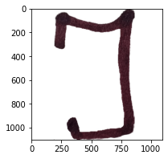

```python
plt.figure(figsize = (3, 3))
plt.imshow(img)
```

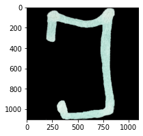

```python
img = cv2.bitwise_not(img)

plt.figure(figsize = (3, 3))
plt.imshow(img)
```

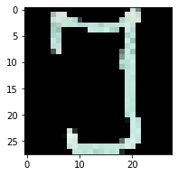

```python
img_fit = cv2.resize(img, (28, 28))

plt.figure(figsize = (3, 3))
plt.imshow(img_fit)
```

```python
params = {'layers': 3, 'vars': ((12, 24, 36), (9, 9, 5)), 'accuracy': 90.94615384615385} #res[0]
print(params)
net_best = NetThreeConv(*params['vars'])
path = '/content/drive/MyDrive/models/three_conv_'+ '_'.join([str(n[0])+'-'+str(n[1])+'-'+str(n[2]) for n in params['vars']]) + '.pth'
net_best.load_state_dict(torch.load(path))
```

```
{'layers': 3, 'vars': ((12, 24, 36), (9, 9, 5)), 'accuracy': 90.94615384615385}
```

```
<All keys matched successfully>
```

```python
PATH = '/content/drive/MyDrive/models/optimal_with_group.pth'
net_best_too = NetThreeConvGroup((24, 48, 96), (9, 9, 9))
net_best_too.load_state_dict(torch.load(PATH))
```

```
<All keys matched successfully>
```

```python
transform_one = transforms.Compose(
    [transforms.ToTensor(),
     transforms.Normalize((0.5, 0.5, 0.5), (0.5, 0.5, 0.5))])
```

```python
classes = test_letter_data.classes
```

```python
from os import listdir

pictures = ['/content/drive/MyDrive/my_letters/'+add for add in listdir('/content/drive/MyDrive/my_letters')]
images = [cv2.imread(add) for add in sorted(pictures)]
images_trans = [transform_one(cv2.resize(cv2.bitwise_not(pic), (28, 28)))  for pic in images]
```

```python
res_conv = []
res_group = []

with torch.no_grad():
  for pic in images_trans:
    outputs1 = net_best(pic.unsqueeze(0))
    outputs2 = net_best_too(pic.unsqueeze(0))
    _, predicted1 = torch.max(outputs1.data, 1)
    _, predicted2 = torch.max(outputs2.data, 1)

    res_conv.append(classes[predicted1])
    res_group.append(classes[predicted2])
    print('Predicted:\t', classes[predicted1], '\t', classes[predicted2])
```

```
Predicted:	 j 	 j
Predicted:	 u 	 u
Predicted:	 l 	 l
Predicted:	 i 	 i
Predicted:	 e 	 a
```

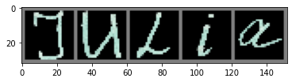

```
Predicted:  j u l i e
	    j u l i a
```

```python
def imshow(img):
  img = img / 2 + 0.5
  npimg = img.numpy()
  plt.imshow(np.transpose(npimg, (1, 2, 0)))
  plt.show()

imshow(torchvision.utils.make_grid(images_trans))
print('Predicted: ', ' '.join(res_conv), '\n\t   ', ' '.join(res_group))
```

Предсказание трехслойной сверточной сети получилось верным на 80%. Определить букву "а" для этой сети оказалось сложным. А точность сверточной сети с применением GroupNorm в данном случае оказалось 100%, модель сработала отлично.

**Задание 2 (1 балл):**

Используйте transfer learning подход для решения задачи - дообучите какую-либо модель, предобученную на ImageNet, для классификации рукописных букв. Оцените качество решения.  
В качестве предобученой модели можно взять одну из [torchvision models](https://pytorch.org/vision/stable/models.html).

```python
import torchvision.models as models
```

```python
mobilenet_v2 = models.mobilenet_v2(pretrained=True)
```

```
Downloading: "https://download.pytorch.org/models/mobilenet_v2-b0353104.pth" to /root/.cache/torch/hub/checkpoints/mobilenet_v2-b0353104.pth
```

```python
mobilenet_v2
```

```
MobileNetV2(
  (features): Sequential(
    (0): ConvNormActivation(
      (0): Conv2d(3, 32, kernel_size=(3, 3), stride=(2, 2), padding=(1, 1), bias=False)
      (1): BatchNorm2d(32, eps=1e-05, momentum=0.1, affine=True, track_running_stats=True)
      (2): ReLU6(inplace=True)
    )
    (1): InvertedResidual(
      (conv): Sequential(
        (0): ConvNormActivation(
          (0): Conv2d(32, 32, kernel_size=(3, 3), stride=(1, 1), padding=(1, 1), groups=32, bias=False)
          (1): BatchNorm2d(32, eps=1e-05, momentum=0.1, affine=True, track_running_stats=True)
          (2): ReLU6(inplace=True)
        )
        (1): Conv2d(32, 16, kernel_size=(1, 1), stride=(1, 1), bias=False)
        (2): BatchNorm2d(16, eps=1e-05, momentum=0.1, affine=True, track_running_stats=True)
      )
    )
    (2): InvertedResidual(
      (conv): Sequential(
        (0): ConvNormActivation(
          (0): Conv2d(16, 96, kernel_size=(1, 1), stride=(1, 1), bias=False)
          (1): BatchNorm2d(96, eps=1e-05, momentum=0.1, affine=True, track_running_stats=True)
          (2): ReLU6(inplace=True)
        )
        (1): ConvNormActivation(
          (0): Conv2d(96, 96, kernel_size=(3, 3), stride=(2, 2), padding=(1, 1), groups=96, bias=False)
          (1): BatchNorm2d(96, eps=1e-05, momentum=0.1, affine=True, track_running_stats=True)
          (2): ReLU6(inplace=True)
        )
        (2): Conv2d(96, 24, kernel_size=(1, 1), stride=(1, 1), bias=False)
        (3): BatchNorm2d(24, eps=1e-05, momentum=0.1, affine=True, track_running_stats=True)
      )
    )
    (3): InvertedResidual(
      (conv): Sequential(
        (0): ConvNormActivation(
          (0): Conv2d(24, 144, kernel_size=(1, 1), stride=(1, 1), bias=False)
          (1): BatchNorm2d(144, eps=1e-05, momentum=0.1, affine=True, track_running_stats=True)
          (2): ReLU6(inplace=True)
```

[output cut: 230 more lines]

```
        (2): Conv2d(960, 320, kernel_size=(1, 1), stride=(1, 1), bias=False)
        (3): BatchNorm2d(320, eps=1e-05, momentum=0.1, affine=True, track_running_stats=True)
      )
    )
    (18): ConvNormActivation(
      (0): Conv2d(320, 1280, kernel_size=(1, 1), stride=(1, 1), bias=False)
      (1): BatchNorm2d(1280, eps=1e-05, momentum=0.1, affine=True, track_running_stats=True)
      (2): ReLU6(inplace=True)
    )
  )
  (classifier): Sequential(
    (0): Dropout(p=0.2, inplace=False)
    (1): Linear(in_features=1280, out_features=1000, bias=True)
  )
)
```

```python
for param in mobilenet_v2.parameters():
    param.requires_grad = False
```

```python
mobilenet_v2.classifier[1] = nn.Linear(1280, 26)
```

```python
mobilenet_v2
```

```
MobileNetV2(
  (features): Sequential(
    (0): ConvNormActivation(
      (0): Conv2d(3, 32, kernel_size=(3, 3), stride=(2, 2), padding=(1, 1), bias=False)
      (1): BatchNorm2d(32, eps=1e-05, momentum=0.1, affine=True, track_running_stats=True)
      (2): ReLU6(inplace=True)
    )
    (1): InvertedResidual(
      (conv): Sequential(
        (0): ConvNormActivation(
          (0): Conv2d(32, 32, kernel_size=(3, 3), stride=(1, 1), padding=(1, 1), groups=32, bias=False)
          (1): BatchNorm2d(32, eps=1e-05, momentum=0.1, affine=True, track_running_stats=True)
          (2): ReLU6(inplace=True)
        )
        (1): Conv2d(32, 16, kernel_size=(1, 1), stride=(1, 1), bias=False)
        (2): BatchNorm2d(16, eps=1e-05, momentum=0.1, affine=True, track_running_stats=True)
      )
    )
    (2): InvertedResidual(
      (conv): Sequential(
        (0): ConvNormActivation(
          (0): Conv2d(16, 96, kernel_size=(1, 1), stride=(1, 1), bias=False)
          (1): BatchNorm2d(96, eps=1e-05, momentum=0.1, affine=True, track_running_stats=True)
          (2): ReLU6(inplace=True)
        )
        (1): ConvNormActivation(
          (0): Conv2d(96, 96, kernel_size=(3, 3), stride=(2, 2), padding=(1, 1), groups=96, bias=False)
          (1): BatchNorm2d(96, eps=1e-05, momentum=0.1, affine=True, track_running_stats=True)
          (2): ReLU6(inplace=True)
        )
        (2): Conv2d(96, 24, kernel_size=(1, 1), stride=(1, 1), bias=False)
        (3): BatchNorm2d(24, eps=1e-05, momentum=0.1, affine=True, track_running_stats=True)
      )
    )
    (3): InvertedResidual(
      (conv): Sequential(
        (0): ConvNormActivation(
          (0): Conv2d(24, 144, kernel_size=(1, 1), stride=(1, 1), bias=False)
          (1): BatchNorm2d(144, eps=1e-05, momentum=0.1, affine=True, track_running_stats=True)
          (2): ReLU6(inplace=True)
```

[output cut: 230 more lines]

```
        (2): Conv2d(960, 320, kernel_size=(1, 1), stride=(1, 1), bias=False)
        (3): BatchNorm2d(320, eps=1e-05, momentum=0.1, affine=True, track_running_stats=True)
      )
    )
    (18): ConvNormActivation(
      (0): Conv2d(320, 1280, kernel_size=(1, 1), stride=(1, 1), bias=False)
      (1): BatchNorm2d(1280, eps=1e-05, momentum=0.1, affine=True, track_running_stats=True)
      (2): ReLU6(inplace=True)
    )
  )
  (classifier): Sequential(
    (0): Dropout(p=0.2, inplace=False)
    (1): Linear(in_features=1280, out_features=26, bias=True)
  )
)
```

```python
run_train(4, mobilenet_v2)
test_model(mobilenet_v2)
```

```
[1,  4000] loss: 2.263, accuracy: 0.350
[2,  4000] loss: 1.994, accuracy: 0.415
[3,  4000] loss: 1.951, accuracy: 0.428
[4,  4000] loss: 1.927, accuracy: 0.436
Finished Training
Accuracy of the network on the 13000 test images: 43.47
```

```
43.46923076923077
```

Без Recize изображения (или просто у этой модели) получились очень плохие результаты.

```python
transform = transforms.Compose(
    [transforms.Resize((64,64)),
     transforms.ToTensor(),
     transforms.Normalize((0.5, 0.5, 0.5), (0.5, 0.5, 0.5)),
     transforms.Lambda(lambda pic: np.transpose(pic, axes=(0, 2, 1)))])
```

```python
train_letter_data = torchvision.datasets.ImageFolder(root = '/content/drive/MyDrive/images/train', transform = transform)
train_letter_loader = torch.utils.data.DataLoader(train_letter_data, batch_size=16, num_workers=2, shuffle=True)
```

```python
test_letter_data = torchvision.datasets.ImageFolder(root = '/content/drive/MyDrive/images/test', transform = transform)
test_letter_loader = torch.utils.data.DataLoader(test_letter_data, batch_size=16, num_workers=2, shuffle=True)
```

```python
vgg19 = models.vgg19(pretrained=True)
vgg19
```

```
Downloading: "https://download.pytorch.org/models/vgg19-dcbb9e9d.pth" to /root/.cache/torch/hub/checkpoints/vgg19-dcbb9e9d.pth
```

```
VGG(
  (features): Sequential(
    (0): Conv2d(3, 64, kernel_size=(3, 3), stride=(1, 1), padding=(1, 1))
    (1): ReLU(inplace=True)
    (2): Conv2d(64, 64, kernel_size=(3, 3), stride=(1, 1), padding=(1, 1))
    (3): ReLU(inplace=True)
    (4): MaxPool2d(kernel_size=2, stride=2, padding=0, dilation=1, ceil_mode=False)
    (5): Conv2d(64, 128, kernel_size=(3, 3), stride=(1, 1), padding=(1, 1))
    (6): ReLU(inplace=True)
    (7): Conv2d(128, 128, kernel_size=(3, 3), stride=(1, 1), padding=(1, 1))
    (8): ReLU(inplace=True)
    (9): MaxPool2d(kernel_size=2, stride=2, padding=0, dilation=1, ceil_mode=False)
    (10): Conv2d(128, 256, kernel_size=(3, 3), stride=(1, 1), padding=(1, 1))
    (11): ReLU(inplace=True)
    (12): Conv2d(256, 256, kernel_size=(3, 3), stride=(1, 1), padding=(1, 1))
    (13): ReLU(inplace=True)
    (14): Conv2d(256, 256, kernel_size=(3, 3), stride=(1, 1), padding=(1, 1))
    (15): ReLU(inplace=True)
    (16): Conv2d(256, 256, kernel_size=(3, 3), stride=(1, 1), padding=(1, 1))
    (17): ReLU(inplace=True)
    (18): MaxPool2d(kernel_size=2, stride=2, padding=0, dilation=1, ceil_mode=False)
    (19): Conv2d(256, 512, kernel_size=(3, 3), stride=(1, 1), padding=(1, 1))
    (20): ReLU(inplace=True)
    (21): Conv2d(512, 512, kernel_size=(3, 3), stride=(1, 1), padding=(1, 1))
    (22): ReLU(inplace=True)
    (23): Conv2d(512, 512, kernel_size=(3, 3), stride=(1, 1), padding=(1, 1))
    (24): ReLU(inplace=True)
    (25): Conv2d(512, 512, kernel_size=(3, 3), stride=(1, 1), padding=(1, 1))
    (26): ReLU(inplace=True)
    (27): MaxPool2d(kernel_size=2, stride=2, padding=0, dilation=1, ceil_mode=False)
    (28): Conv2d(512, 512, kernel_size=(3, 3), stride=(1, 1), padding=(1, 1))
    (29): ReLU(inplace=True)
    (30): Conv2d(512, 512, kernel_size=(3, 3), stride=(1, 1), padding=(1, 1))
    (31): ReLU(inplace=True)
    (32): Conv2d(512, 512, kernel_size=(3, 3), stride=(1, 1), padding=(1, 1))
    (33): ReLU(inplace=True)
    (34): Conv2d(512, 512, kernel_size=(3, 3), stride=(1, 1), padding=(1, 1))
    (35): ReLU(inplace=True)
    (36): MaxPool2d(kernel_size=2, stride=2, padding=0, dilation=1, ceil_mode=False)
  )
  (avgpool): AdaptiveAvgPool2d(output_size=(7, 7))
  (classifier): Sequential(
    (0): Linear(in_features=25088, out_features=4096, bias=True)
    (1): ReLU(inplace=True)
    (2): Dropout(p=0.5, inplace=False)
    (3): Linear(in_features=4096, out_features=4096, bias=True)
    (4): ReLU(inplace=True)
    (5): Dropout(p=0.5, inplace=False)
    (6): Linear(in_features=4096, out_features=1000, bias=True)
  )
)
```

```python
vgg19.classifier[6] = nn.Sequential(nn.Linear(4096, 512), nn.Linear(512, 26))
vgg19
```

```
VGG(
  (features): Sequential(
    (0): Conv2d(3, 64, kernel_size=(3, 3), stride=(1, 1), padding=(1, 1))
    (1): ReLU(inplace=True)
    (2): Conv2d(64, 64, kernel_size=(3, 3), stride=(1, 1), padding=(1, 1))
    (3): ReLU(inplace=True)
    (4): MaxPool2d(kernel_size=2, stride=2, padding=0, dilation=1, ceil_mode=False)
    (5): Conv2d(64, 128, kernel_size=(3, 3), stride=(1, 1), padding=(1, 1))
    (6): ReLU(inplace=True)
    (7): Conv2d(128, 128, kernel_size=(3, 3), stride=(1, 1), padding=(1, 1))
    (8): ReLU(inplace=True)
    (9): MaxPool2d(kernel_size=2, stride=2, padding=0, dilation=1, ceil_mode=False)
    (10): Conv2d(128, 256, kernel_size=(3, 3), stride=(1, 1), padding=(1, 1))
    (11): ReLU(inplace=True)
    (12): Conv2d(256, 256, kernel_size=(3, 3), stride=(1, 1), padding=(1, 1))
    (13): ReLU(inplace=True)
    (14): Conv2d(256, 256, kernel_size=(3, 3), stride=(1, 1), padding=(1, 1))
    (15): ReLU(inplace=True)
    (16): Conv2d(256, 256, kernel_size=(3, 3), stride=(1, 1), padding=(1, 1))
    (17): ReLU(inplace=True)
    (18): MaxPool2d(kernel_size=2, stride=2, padding=0, dilation=1, ceil_mode=False)
    (19): Conv2d(256, 512, kernel_size=(3, 3), stride=(1, 1), padding=(1, 1))
    (20): ReLU(inplace=True)
    (21): Conv2d(512, 512, kernel_size=(3, 3), stride=(1, 1), padding=(1, 1))
    (22): ReLU(inplace=True)
    (23): Conv2d(512, 512, kernel_size=(3, 3), stride=(1, 1), padding=(1, 1))
    (24): ReLU(inplace=True)
    (25): Conv2d(512, 512, kernel_size=(3, 3), stride=(1, 1), padding=(1, 1))
    (26): ReLU(inplace=True)
    (27): MaxPool2d(kernel_size=2, stride=2, padding=0, dilation=1, ceil_mode=False)
    (28): Conv2d(512, 512, kernel_size=(3, 3), stride=(1, 1), padding=(1, 1))
    (29): ReLU(inplace=True)
    (30): Conv2d(512, 512, kernel_size=(3, 3), stride=(1, 1), padding=(1, 1))
    (31): ReLU(inplace=True)
    (32): Conv2d(512, 512, kernel_size=(3, 3), stride=(1, 1), padding=(1, 1))
    (33): ReLU(inplace=True)
    (34): Conv2d(512, 512, kernel_size=(3, 3), stride=(1, 1), padding=(1, 1))
    (35): ReLU(inplace=True)
    (36): MaxPool2d(kernel_size=2, stride=2, padding=0, dilation=1, ceil_mode=False)
  )
  (avgpool): AdaptiveAvgPool2d(output_size=(7, 7))
  (classifier): Sequential(
    (0): Linear(in_features=25088, out_features=4096, bias=True)
    (1): ReLU(inplace=True)
    (2): Dropout(p=0.5, inplace=False)
    (3): Linear(in_features=4096, out_features=4096, bias=True)
    (4): ReLU(inplace=True)
    (5): Dropout(p=0.5, inplace=False)
    (6): Sequential(
      (0): Linear(in_features=4096, out_features=512, bias=True)
      (1): Linear(in_features=512, out_features=26, bias=True)
    )
  )
)
```

```python
run_train(2, vgg19)

PATH = '/content/drive/MyDrive/models/vgg19_full.pth'
torch.save(vgg19.state_dict(), PATH)

test_model(vgg19)
```

[output not shown]

```
94.3923076923077
```

```python
transform = transforms.Compose(
    [transforms.Resize((32,32)),
     transforms.ToTensor(),
     transforms.Normalize((0.5, 0.5, 0.5), (0.5, 0.5, 0.5)),
     transforms.Lambda(lambda pic: np.transpose(pic, axes=(0, 2, 1)))])
```

```python
train_letter_data = torchvision.datasets.ImageFolder(root = '/content/drive/MyDrive/images/train', transform = transform)
train_letter_loader = torch.utils.data.DataLoader(train_letter_data, batch_size=16, num_workers=2, shuffle=True)
```

```python
test_letter_data = torchvision.datasets.ImageFolder(root = '/content/drive/MyDrive/images/test', transform = transform)
test_letter_loader = torch.utils.data.DataLoader(test_letter_data, batch_size=16, num_workers=2, shuffle=True)
```

```python
resnet18 = models.resnet18(pretrained=True)

for param in net.parameters():
    param.requires_grad = False

resnet18.fc = nn.Linear(512, 26)

run_train(4, resnet18)
test_model(resnet18)
```

```
[1,  4000] loss: 0.569, accuracy: 0.826
[2,  4000] loss: 0.279, accuracy: 0.908
[3,  4000] loss: 0.219, accuracy: 0.926
[4,  4000] loss: 0.190, accuracy: 0.934
Finished Training
Accuracy of the network on the 13000 test images: 92.72
```

```
92.72307692307692
```

**Задание 3 (1 балл):**

Добавьте вывод значений функции потерь и accuracy в tensorboard.  
Метрики нужно выводить и для обучающей, и для тестовой выборки.